# AAaaa

Sarah Meilinger

10/18/2020

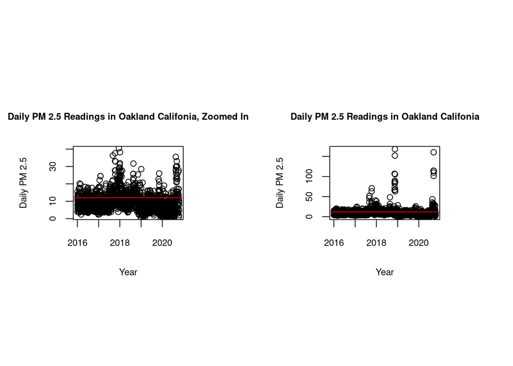

## A table of some things about the numbers

This is a very crude table of Month & mean & standard deviation & N & UCL95 & LCL95

1.00 & 10.20 & 6.39 & 155 & 11.21 & 9.20

2.00 & 8.25 & 4.95 & 142 & 9.07 & 7.44

3.00 & 6.88 & 3.38 & 153 & 7.41 & 6.34

4.00 & 7.95 & 3.94 & 150 & 8.58 & 7.32

5.00 & 7.89 & 4.00 & 155 & 8.52 & 7.26

6.00 & 8.86 & 4.14 & 150 & 9.52 & 8.20

7.00 & 8.70 & 3.65 & 154 & 9.28 & 8.13

8.00 & 11.52 & 7.47 & 155 & 12.70 & 10.35

9.00 & 16.26 & 21.51 & 145 & 19.76 & 12.76

10.00 & 11.29 & 9.35 & 131 & 12.89 & 9.69

11.00 & 18.78 & 28.03 & 120 & 23.80 & 13.77

12.00 & 10.60 & 7.88 & 124 & 11.99 & 9.22

## Health Good? No, Health Bad

This graph shows the air frequently has particle matter of smaller than 2.5 µm over the recommended rate of 12 µg/m3. As Wu et al says in *Exposure to air pollution and COVID-19 mortality in the United States: A nationwide cross-sectional study*, having “an increase of 1 𝜇g/m3in long-term PM 2.5 exposure is associated with an 8% increase in the COVID-19 mortality rate” (Wu et al). Thus, any amount of additional PM2.5 above the recommended amount can have very negative effects on health.

## Thank You

Sarah Meilinger